# Walkthrough of plasmut package use for matched white blood cell and cell-free DNA mutants sequenced

Adith S. Arun and Robert B. Scharpf

2023-02-22

An example workflow of the plasmut package is shown using data from the CAIRO5 study (van’t Erve and Medina et. al 2022). For a group of patients with cancer, both cell-free DNA and white blood cell DNA were sequenced. The distinct and total reads for each mutation present in cell-free DNA are displayed in the data. Corresponding white blood cell total and distinct reads are displayed as well.

From this information, we wish to assign labels to each of the mutations. Specifically, for mutations seen in cell-free DNA and not in white blood cells (distinct reads wbc = 0), we estimate the probability that the mutation arises from the tumor. This is done in a Bayesian framework and approximates integrals as Monte Carlo sums. Please see the paper for a workthrough of the math underlying this. Additionally, for mutations seen in white blood cells and cell-free DNA, we classify them as either hematopoietic or germline variants in an unsupervised manner.

```r
library(plasmut)
library(tidyverse)
library(rjags)
library(ggmcmc)
```

Read in the data and convert columns to their natural types.

```r
extdir <- system.file("extdata", package="plasmut")
fpath <- file.path(extdir, "cairo5-matched-sequencing.csv")

df <- read_csv(fpath, show_col_types=FALSE) %>% type.convert(as.is=TRUE)
```

Here is what a sample of the relevant data from the dataframe looks like:

```r
df %>% select(Gene, Patient, `cfDNA distinct mutant reads`, `cfDNA distinct reads`, `wbc distinct reads`, `wbc distinct mutant reads`) %>% slice(1:4)
```

```
## # A tibble: 4 × 6
##   Gene  Patient `cfDNA distinct mutant reads` `cfDNA distinct…` `wbc distinct …`
##   <chr>   <int>                         <int>             <int>            <int>
## 1 HRAS       12                             4              1541              946
## 2 APC        12                           395              1750              963
## 3 TP53       12                           331              1813              945
## 4 FGFR2      13                             4              2400             1297
## # … with 1 more variable: `wbc distinct mutant reads` <int>
```

Select the relevant columns with total and mutant reads in cfDNA and white blood cell fractions for each mutation. (nw = total WBC reads, np = total cfDNA reads, pw = mutant WBC reads, pw = mutant cfDNA reads)

```r
data <- df %>% select(8:11) %>% magrittr::set_colnames(c("np", "yp", "nw", "yw")) %>% mutate(yw=ifelse(is.na(yw), 0, yw), nw = ifelse(is.na(nw), 1e8, nw)) %>% as.list()
```

Call the plasmut function `compute_p_tumor()` that computes the probability of a mutation being tumor derived.

We can adjust the `rho_ctc_parameter` in the `compute_p_tumor()` function to reflect our apriori assumptions about the fraction of cells in the buffy coat layer that are circulating tumor cells (CTCs). By default, it is assumed that `rho_ctc_parameter = 0`, but this can be changed. A value of 1e-3 may be a good place to start (1 CTC: 1000 WBCs) if CTCs are suspected to be present in the white blood cell fraction.

```r
model_results <- compute_p_tumor(data)
```

The object model_results contains two items, the bayes factors (`model_results$bf`) and the estimated tumor-specific probabilities (`model_results$p`).

Call the plasmut function `stratify_wbc_vars` that identifies which white blood cell mutants are germline versus hematopoietic.

```r
cols <- c("cfDNA distinct mutant reads",
          "cfDNA distinct reads",
          "wbc distinct mutant reads",
          "wbc distinct reads")

wbc.var.type <- stratify_wbc_vars(data=df,
                                  cols=cols)
```

Compute mutant allele fractions (MAFs) for WBC and cell-free fractions. Also, clean data.

```r
df <- df %>%
    mutate(prob.tumor.specific=model_results$p, bayes.factor=model_results$bf,
           wbc.var.type=wbc.var.type) %>%
    mutate(wbcmaf=`wbc distinct mutant reads`/`wbc distinct reads`,
           cfdnamaf=`cfDNA distinct mutant reads`/`cfDNA distinct reads`) %>%
    mutate(cfdnamaf=ifelse(is.nan(cfdnamaf), 0, cfdnamaf))

df <- df %>% filter(g_include == "yes")

df %>% relocate(Gene, Patient, prob.tumor.specific, bayes.factor, cfdnamaf, wbcmaf) %>% head()
```

```
## # A tibble: 6 × 21
##   Gene   Patient prob.tumor.specific bayes.factor cfdnamaf wbcmaf source Date
##   <chr>    <int>               <dbl>        <dbl>    <dbl>  <dbl> <chr>  <chr>
## 1 HRAS        12               0.914      1.07e 1  0.00260      0 plasma 2015-0…
## 2 APC         12               1          3.41e82  0.226        0 plasma 2015-0…
## 3 TP53        12               1          7.72e64  0.183        0 plasma 2015-0…
## 4 FGFR2       13               0.902      9.17e 0  0.00167      0 plasma 2015-0…
## 5 PDGFRA      13               0.843      5.37e 0  0.00104      0 plasma 2015-0…
## 6 PIK3CA      13               1          1.03e19  0.0385       0 plasma 2015-0…
## # … with 13 more variables: Timepoint <chr>, AAChange <chr>,
## #   `Nucleotide Position (hg19)` <chr>, `cfDNA distinct reads` <int>,
## #   `cfDNA distinct mutant reads` <int>, `wbc distinct reads` <int>,
## #   `wbc distinct mutant reads` <int>, type <chr>,
## #   `tumor distinct reads` <chr>, `tumor distinct mutant reads` <chr>,
## #   `mutant tags` <chr>, g_include <chr>, wbc.var.type <int>
```

We can assess the accuracy of our estimation procedure by sequencing the tumor and observing whether the mutation is found there. We sequenced 42 cases where the tumor displayed the same variant as the cell-free DNA. Our estimation procedure assigned a probability of tumor of 1 to 41 of these cases and a probability of 0.998 to the other, which was consistent with the tumor sequencing results.

```r
df %>% select(cfdnamaf, wbcmaf, prob.tumor.specific, type) %>%
    filter(type=="Tumor-confirmed") %>%
    ## @ again, this is an odds and not a probability
    mutate(prob.tumor.specific = round(prob.tumor.specific, 3)) %>%
    group_by(prob.tumor.specific) %>%
    summarize(category=unique(type), n=n())
```

```
## # A tibble: 2 × 3
##   prob.tumor.specific category            n
##                 <dbl> <chr>           <int>
## 1               0.998 Tumor-confirmed     1
## 2               1     Tumor-confirmed    41
```

Finally, we can visualize the results of this approach

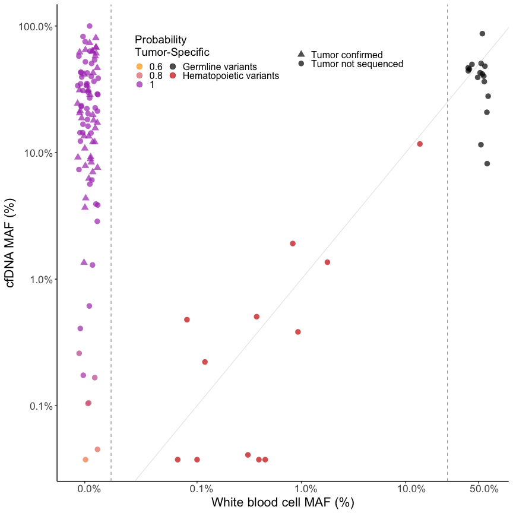

```r
cluster.annotate <- df %>% select(wbc.var.type, cfdnamaf, wbcmaf) %>% group_by(wbc.var.type) %>% summarize(wbclevel=mean(wbcmaf)) %>% arrange(desc(wbclevel)) %>% filter(!is.na(wbc.var.type))

df <- df %>% mutate(status = wbc.var.type) %>% mutate(status = ifelse(is.na(status), "Likely tumor-specific", wbc.var.type)) %>% mutate(status = ifelse(status==cluster.annotate$wbc.var.type[1], "Germline variants", status)) %>% mutate(status = ifelse(status==cluster.annotate$wbc.var.type[2], "Hematopoietic variants", status)) %>% mutate(prob=status) %>% mutate(prob=ifelse(status=="Likely tumor-specific", prob.tumor.specific, prob)) %>% mutate(prob=ifelse(status=="Germline variants", 2, prob), prob=ifelse(status=="Hematopoietic variants", 0, prob)) %>% mutate(prob=as.numeric(prob))

df <- df %>% mutate(shapestatus=ifelse(type=="Tumor-confirmed", "Tumor confirmed", "Tumor not sequenced"))

cfvar_plot <- ggplot(df, aes(x=wbcmaf, y=cfdnamaf)) +
    geom_jitter(aes(color = prob, fill = status, shape=shapestatus),
                fill = "black", stat = "identity", lwd = 3, width = 0.1, alpha = 0.7) +
    scale_color_gradientn(colors = c("red3", "orange", "blue", "black", "black", "orange"),
                          na.value = "transparent",
                          breaks=c(0.6, 0.8, 1, 2, 0),
                          labels=c(0.6, 0.8, 1,"Germline variants", "Hematopoietic variants"),
                          limits=c(0 , 3)) +
    scale_x_continuous(labels = scales::percent_format(accuracy = 0.1),
                       breaks=c(0.000084, 0.001, 0.01,  0.1, 0.5),
                       trans='log10',
                       oob = scales::squish_infinite) +
    scale_y_continuous(labels = scales::percent_format(accuracy = 0.1),
                       breaks=c(0.000084, 0.001, 0.01,  0.1, 1),
                       trans='log10',
                       oob = scales::squish_infinite) +
    scale_shape_manual(values = c(17, 16)) +
    labs(x="White blood cell MAF (%)",
          y="cfDNA MAF (%)")+
    theme_bw() +
    theme(
      plot.background = element_blank(),
      panel.grid.major = element_blank(),
      panel.grid.minor = element_blank(),
      panel.border = element_blank(),
      plot.tag = element_text()) +
    theme(axis.line = element_line(color = 'black')) +
    theme(axis.text.x = element_text(vjust=1.2, hjust= 0.3)) +
    theme(legend.direction = "vertical", legend.box = "horizontal",
          legend.background = element_rect(fill = "transparent"),
          legend.position = c(0.47, 0.88),
          legend.key = element_rect(size = 5), #legend.box.background = element_rect(colour = "black"),
          legend.key.size = unit(0.4, "cm")) +
    guides(color=guide_legend(title="Probability\nTumor-Specific", nrow = 3),
           fill = guide_legend(title=""),
           shape = guide_legend(title="")) +
    geom_vline(xintercept=c(0.00015), linetype="dashed", size = 0.2) +
    geom_vline(xintercept=c(0.00009), linetype="dashed", size = 0.2, color = NA) +
    geom_vline(xintercept=c(0.25), linetype="dashed", size = 0.2) +
    geom_abline(slope=1, intercept=0, color="gray", alpha = 0.4, size = 0.4)

cfvar_plot + theme(axis.title=element_text(size=16), axis.text=element_text(size=13), legend.text=element_text(size=12), legend.title=element_text(size=14))
```

There are a number of mutations with a probability of being tumor specific below 0.9. We can notice that although the white blood cell MAF is zero for these mutations, the number of cell-free DNA mutant reads is very low relative to the total reads. This naturally, introduces some doubt into our minds as to whether the mutant reads are tumor specific, or arising from a different process / tissue. This uncertainty is quantified in our method with reduced probability estimates, something a binary “tumor or not” approach does not capture.

```r
df %>% filter(wbcmaf == 0) %>% arrange(prob) %>% select(prob, `cfDNA distinct mutant reads`, `cfDNA distinct reads`, `wbc distinct mutant reads`, `wbc distinct reads`, type, Gene, Patient) %>% slice(1:10)
```

```
## # A tibble: 10 × 8
##     prob `cfDNA distinct mu…` `cfDNA distinc…` `wbc distinct …` `wbc distinct …`
##    <dbl>                <int>            <int>            <int>            <int>
##  1 0.711                    1             2667                0             1544
##  2 0.765                    1             2213                0             1566
##  3 0.843                    4             3842                0             1538
##  4 0.843                    4             3796                0             1671
##  5 0.902                    4             2400                0             1297
##  6 0.914                    4             1541                0              946
##  7 0.973                    4             2298                0             2436
##  8 0.996                   12             2944                0             1562
##  9 0.998                    2              148                0             1138
## 10 0.999                    7             1140                0             1748
## # … with 3 more variables: type <chr>, Gene <chr>, Patient <int>
```

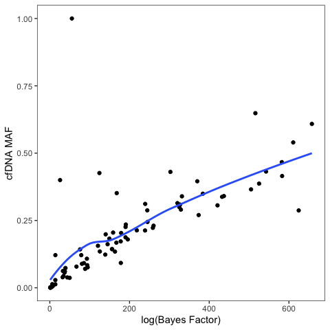

The accuracy of our method can be assessed by noting the concordance between tile outlines and colors. For example, bayes factor > 18.01 outlined tiles almost always have a color corresponding to tumor and bayes factor < 18.01 tiles almost always have a germline or hematopoietic color.

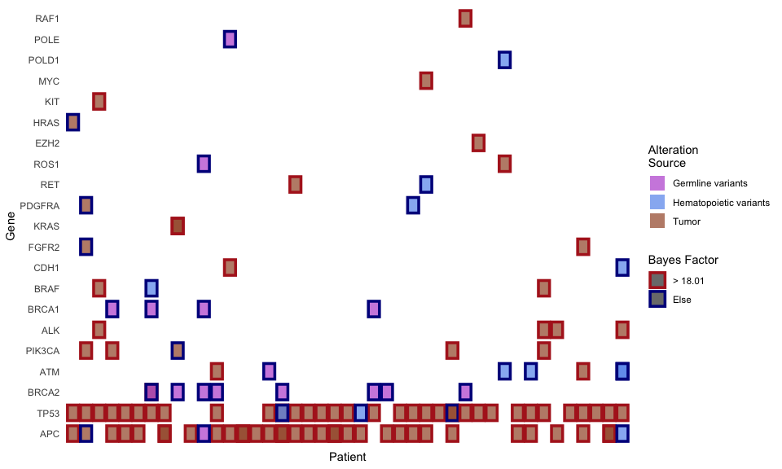

```r
plt.df <- df %>% select(status, Gene, Patient, bayes.factor) %>% mutate(border=ifelse(bayes.factor > 18.01, "> 18.01", "Else")) %>% select(-bayes.factor) %>% mutate(alt.source=ifelse(status=="Likely tumor-specific", "Tumor", status)) %>% select(-status)

ordered.levels <- plt.df %>% group_by(Gene) %>% summarize(n=n()) %>% arrange(desc(n)) %>% pull(Gene)

gene.numbers <- plt.df %>% select(Gene) %>% distinct() %>% mutate(gene.num=1:n())

plt.df <- plt.df %>% left_join(gene.numbers, by=c("Gene"="Gene"))

fig <- plt.df %>% ggplot(aes(y=factor(Gene, levels=ordered.levels), x=factor(Patient), fill=alt.source, color=border)) + geom_tile(size=1.25, alpha=0.7, width=0.85, height=0.75) + theme_minimal() + ylab("Gene") + xlab("Patient") + theme(panel.grid.major=element_blank()) + theme(axis.text.x=element_blank()) + scale_color_manual(values=c("firebrick", "darkblue"), name="Bayes Factor") + scale_fill_manual(values=c("mediumorchid", "cornflowerblue", "sienna"), name="Alteration\nSource")

fig
```